# Big Data Statistics for R and Python

25/03/2019

## Updates

## Group Examination of Part I

- 25 points max.
  - 15 points: Implementation of specific tasks.
  - 10 points: Own extension of the research report (1-2 pages).
- Final grade 50% (25 points) group examination task + 50% (25 points) oral exam (Part II).
- Release: This Friday, 17:00.

## Test registration of groups

## Schedule

1. Introduction: Big Data, Data Economy (Concepts). M: Walkowiak (2016): Chapter 1
2. Programming with Data, R Refresher Course (Concepts/Applied). M: Walkowiak (2016): Chapter 2
3. Computation and Memory (Concepts)
4. Cleaning and Transformation of Big Data (Applied). M: Walkowiak (2016): Chapter 3: p. 74‐118.
5. Aggregation and Visualization (Applied: data tables, ggplot). M: Walkowiak (2016): Chapter 3: p. 118‐127. C: Wickham et al. (2015), Schwabish (2014).
6. *Data Storage, Databases Interaction with R. M: Walkowiak (2016): Chapter 5.*
7. Distributed Systems, MapReduce/Hadoop with R (Concepts/Applied). M: Walkowiak (2016): Chapter 4.

## Data Visualization Part II

## Visualization of spatial data with `ggplot2`

- Data source: NYC Taxi & Limousine Commission (TLC).
- Data on all trip records including *pick-up and drop-off times/locations*.

## Preparations

- Load packages for GIS data/operations

```r
# load GIS packages
library(rgdal)
library(rgeos)
```

## Download map data

```r
# download the zipped shapefile to a temporary file, unzip
URL <- "https://www1.nyc.gov/assets/planning/download/zip/data-maps/open-data/nycd_19a.zip"
tmp_file <- tempfile()
download.file(URL, tmp_file)
file_path <- unzip(tmp_file, exdir= "../data")
# delete the temporary file
unlink(tmp_file)
```

## Import map data

```r
# read GIS data
nyc_map <- readOGR(file_path[1], verbose = FALSE)

# have a look at the polygons that constitute the map
summary(nyc_map)
```

```
## Object of class SpatialPolygonsDataFrame
## Coordinates:
##        min       max
## x 913175.1 1067382.5
## y 120121.9  272844.3
## Is projected: TRUE
## proj4string :
## [+proj=lcc +lat_1=40.66666666666666 +lat_2=41.03333333333333 +lat_0=40.16666666666666
## +lon_0=-74 +x_0=300000 +y_0=0 +datum=NAD83 +units=us-ft +no_defs +ellps=GRS80
## +towgs84=0,0,0]
## Data attributes:
##      BoroCD        Shape_Leng       Shape_Area
##  Min.   :101.0   Min.   : 23963   Min.   : 24293239
##  1st Qu.:205.5   1st Qu.: 36611   1st Qu.: 48407357
##  Median :308.0   Median : 52246   Median : 82702417
##  Mean   :297.2   Mean   : 74890   Mean   :118724012
##  3rd Qu.:405.5   3rd Qu.: 85711   3rd Qu.:136615357
##  Max.   :595.0   Max.   :270660   Max.   :599062130
```

## Change map projection

```r
# transform the projection
nyc_map <- spTransform(nyc_map,
                       CRS("+proj=longlat +datum=WGS84 +no_defs +ellps=WGS84 +towgs84=0,0,0"))
# check result
summary(nyc_map)
```

```
## Object of class SpatialPolygonsDataFrame
## Coordinates:
##         min       max
## x -74.25559 -73.70001
## y  40.49612  40.91553
## Is projected: FALSE
## proj4string :
## [+proj=longlat +datum=WGS84 +no_defs +ellps=WGS84 +towgs84=0,0,0]
## Data attributes:
##      BoroCD        Shape_Leng       Shape_Area
##  Min.   :101.0   Min.   : 23963   Min.   : 24293239
##  1st Qu.:205.5   1st Qu.: 36611   1st Qu.: 48407357
##  Median :308.0   Median : 52246   Median : 82702417
##  Mean   :297.2   Mean   : 74890   Mean   :118724012
##  3rd Qu.:405.5   3rd Qu.: 85711   3rd Qu.:136615357
##  Max.   :595.0   Max.   :270660   Max.   :599062130
```

## Prepare map for plotting with `ggplot2`

```r
nyc_map <- fortify(nyc_map)
```

## Prepare pick-up and drop-off data

```r
# taxi trips plot data
taxi_trips <- taxi[start_long <= max(nyc_map$long) &
                        start_long >= min(nyc_map$long) &
                        dest_long <= max(nyc_map$long) &
                        dest_long >= min(nyc_map$long) &
                        start_lat <= max(nyc_map$lat) &
                        start_lat >= min(nyc_map$lat) &
                        dest_lat <= max(nyc_map$lat) &
                        dest_lat >= min(nyc_map$lat)
                        ]
taxi_trips <- taxi_trips[sample(nrow(taxi_trips), 50000)]
```

## Code time dimension(s)

```r
taxi_trips$start_time <- hour(taxi_trips$pickup_time)
```

```r
# define new variable for facets
taxi_trips$time_of_day <- "Morning"
taxi_trips[start_time > 12 & start_time < 17]$time_of_day <- "Afternoon"
taxi_trips[start_time %in% c(17:24, 0:5)]$time_of_day <- "Evening/Night"
taxi_trips$time_of_day  <- factor(taxi_trips$time_of_day, levels = c("Morning", "Afternoon", "Evening/Night"))
```

## Base plot: Map of NYC

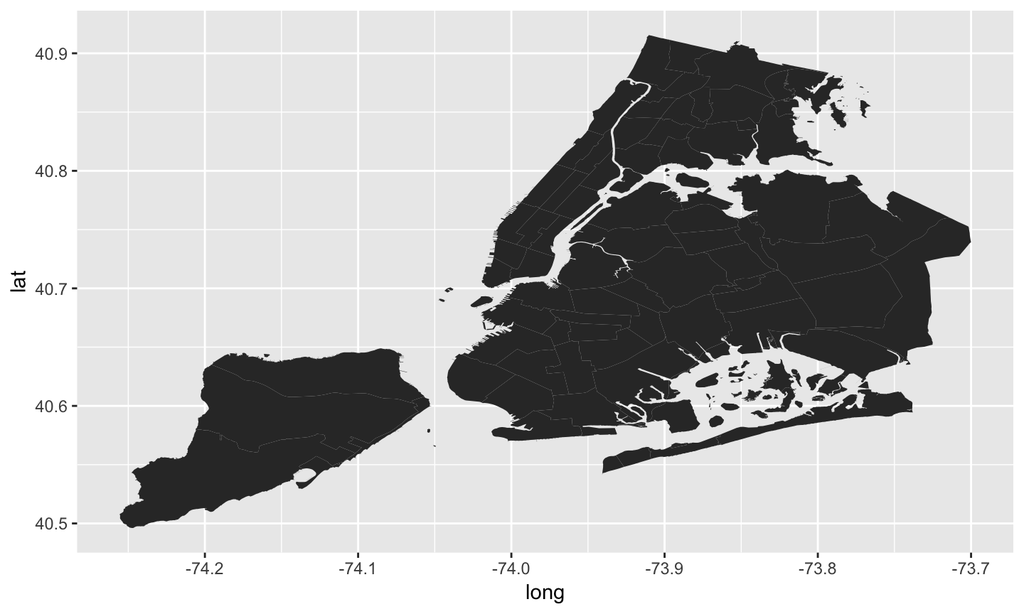

```r
# set up the canvas
locations <- ggplot(taxi_trips, aes(x=long, y=lat))
# add the map geometry
locations <- locations + geom_map(data = nyc_map,
                                  map = nyc_map,
                                  aes(map_id = id))
locations
```

## Add pick-up locations

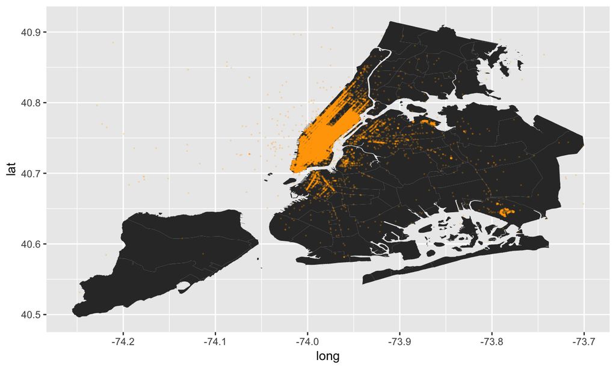

```r
# add pick-up locations to plot
locations +
     geom_point(aes(x=start_long, y=start_lat),
                color="orange",
                size = 0.1,
                alpha = 0.2)
```

## Add drop-off locations

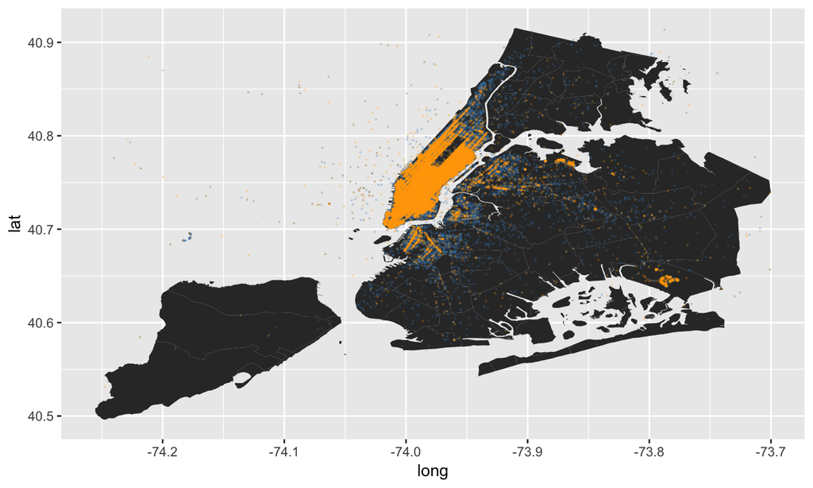

```r
# add pick-up locations to plot
locations +
     geom_point(aes(x=dest_long, y=dest_lat),
                color="steelblue",
                size = 0.1,
                alpha = 0.2) +
     geom_point(aes(x=start_long, y=start_lat),
                color="orange",
                size = 0.1,
                alpha = 0.2)
```

## Taxi traffic over the course of a day

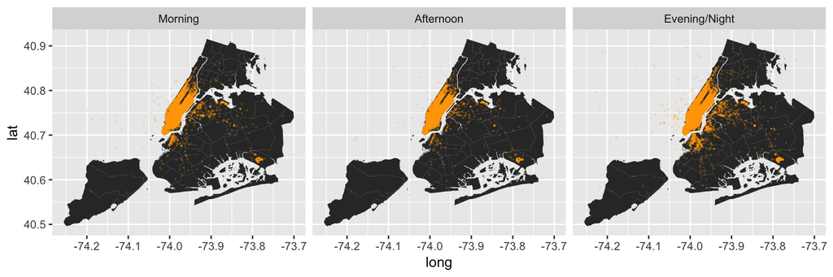

```r
# pick-up locations
locations +
     geom_point(aes(x=start_long, y=start_lat),
                color="orange",
                size = 0.1,
                alpha = 0.2) +
     facet_wrap(vars(time_of_day))
```

## Taxi traffic over the course of a day

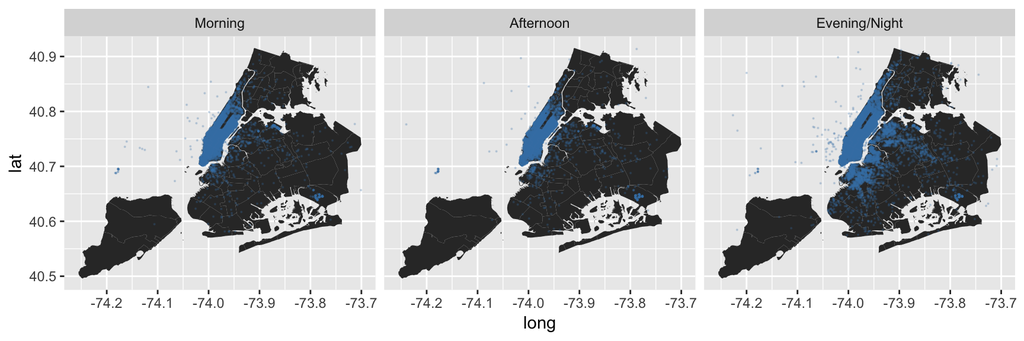

```r
# drop-off locations
locations +
     geom_point(aes(x=dest_long, y=dest_lat),
                color="steelblue",
                size = 0.1,
                alpha = 0.2) +
     facet_wrap(vars(time_of_day))
```

## Taxi traffic over the course of a day

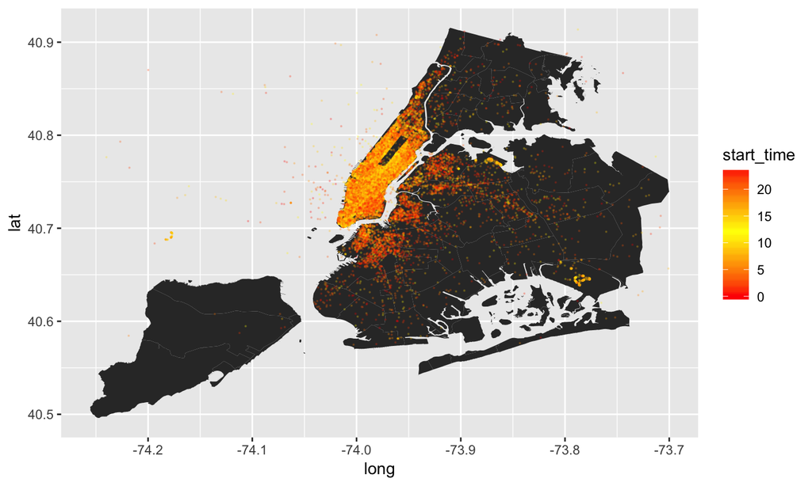

```r
# drop-off locations
locations +
     geom_point(aes(x=dest_long, y=dest_lat, color = start_time ),
                size = 0.1,
                alpha = 0.2) +
     scale_colour_gradient2( low = "red", mid = "yellow", high = "red",
                             midpoint = 12)
```

## Data Storage and Databases

## (Big) Data Storage

- \((I)\) How can we store large data sets permanently on a mass storage device in an efficient way (here, efficient can be understood as 'not taking up too much space')?
- \((II)\) How can we load (parts of) this data set in an efficient way (here, efficient~fast) for analysis?

## We look at this problem in two situations:

- The data need to be stored locally (e.g., on the hard disk of our laptop).
- The data can be stored on a server 'in the cloud' (next lecture).

## Many new database types for Big Data

[figure not shown]

NoSQL/NewSQL systems. Source: https://img.deusm.com/informationweek/2014/06/1269559/NoSQL-&-NewSQL.jpg

## Simple distinction

- *SQL/Relational Database Systems (RDBMS)*: Relational data model, tabular relations.
  - In use for a long time, very mature, very accurate/stable.
- *NoSQL ('non-SQL', sometimes 'Not only SQL')*: Different data models, column, document, key-value, graph.
  - Horizontal scaling.
  - Non-tabular data.
  - Typically used to handle very large amounts of data.

## RDBMS basics

- *Relational data model*
  - Data split into several tables (avoid redundancies).
  - Tables are linked via key-variables/columns.
  - Save storage space.
- *Indexing*
  - Table columns (particularly keys) are indexed.
  - Reduces number of disk accesses required to query data.
  - Makes querying/loading of data more efficient/faster.

## Getting started with (R)SQLite

- [SQLite](https://sqlite.org/index.html)
  - Free, full-featured SQL database engine.
  - Widely used across platforms.
  - Typically pre-installed on Windows/MacOSX.
- [RSQLite](https://cran.r-project.org/web/packages/RSQLite/index.html)
  - Embeds SQLite in R.
  - Use SQLite from within an R session.

## Exercise 1: First steps in SQLite (Terminal)

- Set up a new database called `mydb.sqlite`.

```bash
cd materials/data
```

```bash
sqlite3 mydb.sqlite
```

```sql
.tables
```

## Import data from CSV files

```sql
CREATE TABLE econ(
"date" DATE,
"pce" REAL,
"pop" INTEGER,
"psavert" REAL,
"uempmed" REAL,
"unemploy" INTEGER
);

.mode csv
.import economics.csv econ
```

## Inspect the database

```
.tables
```

```
# econ
```

```
.schema econ
```

```
# CREATE TABLE econ(
# "date" DATE,
# "pce" REAL,
# "pop" INTEGER,
# "psavert" REAL,
# "uempmed" REAL,
# "unemploy" INTEGER
# );
```

## Set options for output

```sql
.header on
```

```sql
.mode columns
```

## Issue queries: Example 1

In our first query, we select all (`*`) variable values of the observation of January 1968.

```sql
select * from econ where date = '1968-01-01'
```

1 records

| date | pce | pop | psavert | uempmed | unemploy |
| --- | --- | --- | --- | --- | --- |
| 1968-01-01 | 531.5 | 199808 | 11.7 | 5.1 | 2878 |

## Issue queries: Example 2

Now let's select all year/months in which there were more than 15 million unemployed, ordered by date.

```sql
select date from econ
where unemploy > 15000
order by date;
```

Displaying records 1 - 10

[output not shown]

## Close SQLite

When done working with the database, we can exit SQLite with the `.quit` command.

## Exercise 2: Indices and joins

- Import several related tables.
- Add indices to tables.

## Initiate DB, import data

We set up a new database called `air.sqlite` and import the csv-file `flights.csv` (used in previous lectures) as a first table.

```bash
# create database and run sqlite
sqlite3 air.sqlite
```

## Import data from CSVs

```sql
.mode csv
.import flights.csv flights
```

## Inspect the `flights` table

Again, we can check if everything worked out well with `.tables` and `.schema`.

```sql
.tables
.schema flights
```

## Related tables

- [`airports.csv`](http://stat-computing.org/dataexpo/2009/airports.csv): Describes the locations of US Airports (relates to `origin` and `dest`).
- [`carriers.csv`](http://stat-computing.org/dataexpo/2009/carriers.csv): A listing of carrier codes with full names (relates to the `carrier`-column in `flights`.

## Import related tables

Import from csv-file

```sql
.mode csv
.import airports.csv airports
.import carriers.csv carriers
```

Inspect the result

```sql
.tables
.schema airports
.schema carriers
```

## Issue queries with joins

- Goal: A table containing flights data for all `United Air Lines Inc.`-flights departing from `Newark Intl` airport, ordered by flight number.
- For the sake of the exercise, we only show the first 10 results of this query (`LIMIT 10`).

## Issue queries with joins

```sql
SELECT
year,
month,
day,
dep_delay,
flight
FROM (flights INNER JOIN airports ON flights.origin=airports.iata)
INNER JOIN carriers ON flights.carrier = carriers.Code
WHERE carriers.Description = 'United Air Lines Inc.'
AND airports.airport = 'Newark Intl'
ORDER BY flight
LIMIT 10;
```

Displaying records 1 - 10

| year | month | day | dep_delay | flight |
| --- | --- | --- | --- | --- |
| 2013 | 1 | 4 | 0 | 1 |
| 2013 | 1 | 5 | -2 | 1 |
| 2013 | 3 | 6 | 1 | 1 |
| 2013 | 2 | 13 | -2 | 3 |
| 2013 | 2 | 16 | -9 | 3 |
| 2013 | 2 | 20 | 3 | 3 |
| 2013 | 2 | 23 | -5 | 3 |
| 2013 | 2 | 26 | 24 | 3 |
| 2013 | 2 | 27 | 10 | 3 |
| 2013 | 1 | 5 | 3 | 10 |

## Add indices

```sql
CREATE INDEX iata_airports ON airports (iata);
CREATE INDEX origin_flights ON flights (origin);
CREATE INDEX carrier_flights ON flights (carrier);
CREATE INDEX code_carriers ON carriers (code);
```

## Re-run the query (with indices)

```sql
SELECT
year,
month,
day,
dep_delay,
flight
FROM (flights INNER JOIN airports ON flights.origin=airports.iata)
INNER JOIN carriers ON flights.carrier = carriers.Code
WHERE carriers.Description = 'United Air Lines Inc.'
AND airports.airport = 'Newark Intl'
ORDER BY flight
LIMIT 10;
```

Displaying records 1 - 10

| year | month | day | dep_delay | flight |
| --- | --- | --- | --- | --- |
| 2013 | 1 | 4 | 0 | 1 |
| 2013 | 1 | 5 | -2 | 1 |
| 2013 | 3 | 6 | 1 | 1 |
| 2013 | 2 | 13 | -2 | 3 |
| 2013 | 2 | 16 | -9 | 3 |
| 2013 | 2 | 20 | 3 | 3 |
| 2013 | 2 | 23 | -5 | 3 |
| 2013 | 2 | 26 | 24 | 3 |
| 2013 | 2 | 27 | 10 | 3 |
| 2013 | 1 | 5 | 3 | 10 |

## SQLite from within R

- Use `RSQLite` to set up and query `air.sqlite` as shown above.
- All done from within an R session.

## Creating a new database with `RSQLite`

```r
# load packages
library(RSQLite)

# initiate the database
con_air <- dbConnect(SQLite(), "../data/air.sqlite")
```

## Importing data

```r
# import data into current R sesssion
flights <- fread("../data/flights.csv")
airports <- fread("../data/airports.csv")
carriers <- fread("../data/carriers.csv")

# add tables to database
dbWriteTable(con_air, "flights", flights)
dbWriteTable(con_air, "airports", airports)
dbWriteTable(con_air, "carriers", carriers)
```

## Issue queries with `RSQLite`

```r
# define query
delay_query <-
"SELECT
year,
month,
day,
dep_delay,
flight
FROM (flights INNER JOIN airports ON flights.origin=airports.iata)
INNER JOIN carriers ON flights.carrier = carriers.Code
WHERE carriers.Description = 'United Air Lines Inc.'
AND airports.airport = 'Newark Intl'
ORDER BY flight
LIMIT 10;
"
```

## Issue queries with `RSQLite`

```r
# issue query
delays_df <- dbGetQuery(con_air, delay_query)
delays_df
```

```
##    year month day dep_delay flight
## 1  2013     1   4         0      1
## 2  2013     1   5        -2      1
## 3  2013     3   6         1      1
## 4  2013     2  13        -2      3
## 5  2013     2  16        -9      3
## 6  2013     2  20         3      3
## 7  2013     2  23        -5      3
## 8  2013     2  26        24      3
## 9  2013     2  27        10      3
## 10 2013     1   5         3     10
```

## Close the connection to SQLite

```r
dbDisconnect(con_air)
```